# Lab 03 - Exploratory Data Analysis

January 22, 2025

# Learning Goals

- Read in and get familiar with the meteorology dataset
- Step through the EDA “checklist” presented in the class slides
- Practice making exploratory graphs

# Lab Description

We will work with the meteorological data presented in lecture. Recall the dataset consists of weather station readings in the contiguous US.

**The objective of the lab is to find the weather station with the highest elevation and look at patterns in the time series of its wind speed and temperature.**

# Steps

### 1. Read in the data

First download and then read in with `data.table` function `fread()`

```r
download.file(
  "https://raw.githubusercontent.com/JSC370/JSC370-2025/main/data/met/met_all.gz",
  destfile = "met_all.gz",
  method   = "curl",
  timeout  = 60
  )

met <- data.table::fread("met_all.gz")
```

### 2. Check the dimensions, headers, footers. How many columns, rows are there?

- Note you may use R or Python

```r
# <place your code here>

dim(met)
```

```
## [1] 2377343      30
```

```r
head(met)
```

| USAFID | WBAN | year | month | day | hour | min | lat | lon | elev | wind.dir | wind.dir.qc | wind.type.code | wind.sp | wind.sp.qc | ceiling.ht | ceiling.ht.qc | ceiling.ht.method | sky.cond | vis.dist | vis.dist.qc | vis.var | vis.var.qc | temp | temp.qc | dew.point | dew.point.qc | atm.press | atm.press.qc | rh |
| --- | --- | --- | --- | --- | --- | --- | --- | --- | --- | --- | --- | --- | --- | --- | --- | --- | --- | --- | --- | --- | --- | --- | --- | --- | --- | --- | --- | --- | --- |
| 690150 | 93121 | 2019 | 8 | 1 | 0 | 56 | 34.3 | -116.166 | 696 | 220 | 5 | N | 5.7 | 5 | 22000 | 5 | 9 | N | 16093 | 5 | N | 5 | 37.2 | 5 | 10.6 | 5 | 1009.9 | 5 | 19.88127 |
| 690150 | 93121 | 2019 | 8 | 1 | 1 | 56 | 34.3 | -116.166 | 696 | 230 | 5 | N | 8.2 | 5 | 22000 | 5 | 9 | N | 16093 | 5 | N | 5 | 35.6 | 5 | 10.6 | 5 | 1010.3 | 5 | 21.76098 |
| 690150 | 93121 | 2019 | 8 | 1 | 2 | 56 | 34.3 | -116.166 | 696 | 230 | 5 | N | 6.7 | 5 | 22000 | 5 | 9 | N | 16093 | 5 | N | 5 | 34.4 | 5 | 7.2 | 5 | 1010.6 | 5 | 18.48212 |
| 690150 | 93121 | 2019 | 8 | 1 | 3 | 56 | 34.3 | -116.166 | 696 | 210 | 5 | N | 5.1 | 5 | 22000 | 5 | 9 | N | 16093 | 5 | N | 5 | 33.3 | 5 | 5.0 | 5 | 1011.6 | 5 | 16.88862 |
| 690150 | 93121 | 2019 | 8 | 1 | 4 | 56 | 34.3 | -116.166 | 696 | 120 | 5 | N | 2.1 | 5 | 22000 | 5 | 9 | N | 16093 | 5 | N | 5 | 32.8 | 5 | 5.0 | 5 | 1012.7 | 5 | 17.38410 |
| 690150 | 93121 | 2019 | 8 | 1 | 5 | 56 | 34.3 | -116.166 | 696 | NA | 9 | C | 0.0 | 5 | 22000 | 5 | 9 | N | 16093 | 5 | N | 5 | 31.1 | 5 | 5.6 | 5 | 1012.7 | 5 | 20.01540 |

```r
tail(met)
```

| USAFID | WBAN | year | month | day | hour | min | lat | lon | elev | wind.dir | wind.dir.qc | wind.type.code | wind.sp | wind.sp.qc | ceiling.ht | ceiling.ht.qc | ceiling.ht.method | sky.cond | vis.dist | vis.dist.qc | vis.var | vis.var.qc | temp | temp.qc | dew.point | dew.point.qc | atm.press | atm.press.qc | rh |
| --- | --- | --- | --- | --- | --- | --- | --- | --- | --- | --- | --- | --- | --- | --- | --- | --- | --- | --- | --- | --- | --- | --- | --- | --- | --- | --- | --- | --- | --- |
| 726813 | 94195 | 2019 | 8 | 31 | 18 | 56 | 43.650 | -116.633 | 741 | NA | 9 | C | 0.0 | 5 | 22000 | 5 | 9 | N | 16093 | 5 | N | 5 | 30.0 | 5 | 11.7 | 5 | 1013.6 | 5 | 32.32509 |
| 726813 | 94195 | 2019 | 8 | 31 | 19 | 56 | 43.650 | -116.633 | 741 | 70 | 5 | N | 2.1 | 5 | 22000 | 5 | 9 | N | 16093 | 5 | N | 5 | 32.2 | 5 | 12.2 | 5 | 1012.8 | 5 | 29.40686 |
| 726813 | 94195 | 2019 | 8 | 31 | 20 | 56 | 43.650 | -116.633 | 741 | NA | 9 | C | 0.0 | 5 | 22000 | 5 | 9 | N | 16093 | 5 | N | 5 | 33.3 | 5 | 12.2 | 5 | 1011.6 | 5 | 27.60422 |
| 726813 | 94195 | 2019 | 8 | 31 | 21 | 56 | 43.650 | -116.633 | 741 | 10 | 5 | N | 2.6 | 5 | 22000 | 5 | 9 | N | 14484 | 5 | N | 5 | 35.0 | 5 | 9.4 | 5 | 1010.8 | 5 | 20.76325 |
| 726813 | 94195 | 2019 | 8 | 31 | 22 | 56 | 43.642 | -116.636 | 741 | 10 | 1 | N | 2.1 | 1 | 22000 | 1 | 9 | N | 16093 | 1 | 9 | 9 | 34.4 | 1 | 9.4 | 1 | 1010.1 | 1 | 21.48631 |
| 726813 | 94195 | 2019 | 8 | 31 | 23 | 56 | 43.642 | -116.636 | 741 | 40 | 1 | N | 2.1 | 1 | 22000 | 1 | 9 | N | 16093 | 1 | 9 | 9 | 34.4 | 1 | 9.4 | 1 | 1009.6 | 1 | 21.48631 |

- *Summarize here* There are 2377343 observations 30 columns.

### 3. Take a look at the variables in the dataset. What kind of variables are there?

```r
# <place your code here>
str(met)
```

```
## Classes 'data.table' and 'data.frame':   2377343 obs. of  30 variables:
##  $ USAFID           : int  690150 690150 690150 690150 690150 690150 690150 690150 690150 690150 ...
##  $ WBAN             : int  93121 93121 93121 93121 93121 93121 93121 93121 93121 93121 ...
##  $ year             : int  2019 2019 2019 2019 2019 2019 2019 2019 2019 2019 ...
##  $ month            : int  8 8 8 8 8 8 8 8 8 8 ...
##  $ day              : int  1 1 1 1 1 1 1 1 1 1 ...
##  $ hour             : int  0 1 2 3 4 5 6 7 8 9 ...
##  $ min              : int  56 56 56 56 56 56 56 56 56 56 ...
##  $ lat              : num  34.3 34.3 34.3 34.3 34.3 34.3 34.3 34.3 34.3 34.3 ...
##  $ lon              : num  -116 -116 -116 -116 -116 ...
##  $ elev             : int  696 696 696 696 696 696 696 696 696 696 ...
##  $ wind.dir         : int  220 230 230 210 120 NA 320 10 320 350 ...
##  $ wind.dir.qc      : chr  "5" "5" "5" "5" ...
##  $ wind.type.code   : chr  "N" "N" "N" "N" ...
##  $ wind.sp          : num  5.7 8.2 6.7 5.1 2.1 0 1.5 2.1 2.6 1.5 ...
```

[output cut: 17 more lines]

- *Summarize here* There are integers, strings and floats in the dataset.

### 4. Take a closer look at the key variables.

- Are there missing data? If so, make sure they are coded correctly.
- Are there any unusual values that look suspicious? Recall the temperature values in the lecture.

```r
# <place your code here>

table(met$year)
```

```
##
##    2019
## 2377343
```

```r
table(met$day)
```

```
##
##     1     2     3     4     5     6     7     8     9    10    11    12    13
## 75975 75923 76915 76594 76332 76734 77677 77766 75366 75450 76187 75052 76906
##    14    15    16    17    18    19    20    21    22    23    24    25    26
## 77852 76217 78015 78219 79191 76709 75527 75786 78312 77413 76965 76806 79114
##    27    28    29    30    31
## 79789 77059 71712 74931 74849
```

```r
table(met$hour)
```

```
##
##      0      1      2      3      4      5      6      7      8      9     10
##  99434  93482  93770  96703 110504 112128 106235 101985 100310 102915 101880
##     11     12     13     14     15     16     17     18     19     20     21
## 100470 103605  97004  96507  97635  94942  94184 100179  94604  94928  96070
##     22     23
##  94046  93823
```

```r
summary(met$temp)
```

```
##    Min. 1st Qu.  Median    Mean 3rd Qu.    Max.    NA's
##  -40.00   19.60   23.50   23.59   27.80   56.00   60089
```

```r
summary(met$elev)
```

```
##    Min. 1st Qu.  Median    Mean 3rd Qu.    Max.
##   -13.0   101.0   252.0   415.8   400.0  9999.0
```

```r
summary(met$wind.sp)
```

```
##    Min. 1st Qu.  Median    Mean 3rd Qu.    Max.    NA's
##    0.00    0.00    2.10    2.46    3.60   36.00   79693
```

- *Summarize here*

The temperatue has a max of 56 and min of -40. This range of values is out of the ordinary for August. There are 60k N/A values for temperature data. Additionally, the max elevation of 9999 is an unlikely to appear in reality and -13 elevation indicates the weather measurements were taken underground or underwater. The range of wind speeds seems reasonable but there are ~80k missing values.Gooogle search shows the max elevation in USA is (6,194 meters) < 9999. Our dataset likely used 9999 as a filler value to represent missing data or an arbitrary condition.

### 5. Check the data against an external data source and make adjustments.

- Check that the range of elevations make sense.
- Google or ChatGPT is your friend here.
- Fix any problems that arise in your checks.

```r
# <place your code here>
met$elev[met$elev == 9999] <- NA
met$temp[met$temp == -40] <- NA
summary(met$elev)
```

```
##    Min. 1st Qu.  Median    Mean 3rd Qu.    Max.    NA's
##     -13     101     252     413     400    4113     710
```

```r
summary(met$temp)
```

```
##    Min. 1st Qu.  Median    Mean 3rd Qu.    Max.    NA's
##  -17.20   19.60   23.50   23.59   27.80   56.00   60125
```

- *Summarize anything that was removed* These results are more reasonable, with a max elev. of 4113 likely to be at the top of the Rocky Mountains.

### 6. Calculate summary statistics

Remember to keep the initial question in mind. We want to pick out the weather station with maximum elevation and examine its wind speed and temperature.

Some ideas: 1. select the weather station with maximum elevation; 2. look at the correlation between temperature and wind speed; and 3. look at the correlation between temperature and wind speed with hour and day of the month.

```r
# <place your code here>
ss_met = met[, c(1:10, 14, 24)]
met_clean <- na.omit(ss_met)
met_clean <- met_clean[elev == max(met_clean$elev)]

cor(met_clean$temp, met_clean$wind.sp)
```

```
## [1] -0.09373843
```

```r
cor(met_clean$temp, met_clean$hour)
```

```
## [1] 0.4356801
```

```r
cor(met_clean$temp, met_clean$day)
```

```
## [1] -0.006130763
```

```r
cor(met_clean$wind.sp, met_clean$hour)
```

```
## [1] 0.08807315
```

```r
cor(met_clean$wind.sp, met_clean$day)
```

```
## [1] 0.3643079
```

### 7. At what elevation is the highest weather station?

```r
# <place your code here>
max(met_clean$elev)
```

```
## [1] 4113
```

- *Summarize here* It is at 4113 meters.

### 8. Exploratory graphs: Distributions

We should look at the distributions of all of the key variables (elevation, temp, wind speed) to make sure there are no remaining issues with the data.

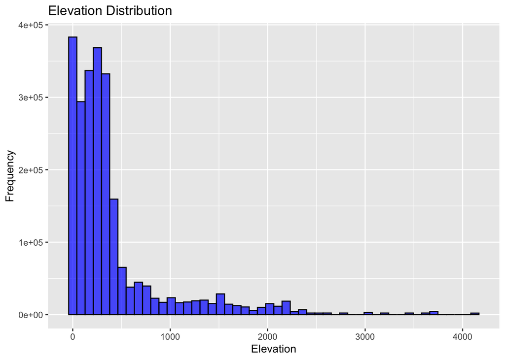

```r
# <place your code here>

ggplot(ss_met, aes(x = elev)) +
  geom_histogram(bins=50, fill = "blue", color = "black", alpha = 0.7) +
  labs(title = "Elevation Distribution", x = "Elevation", y = "Frequency")
```

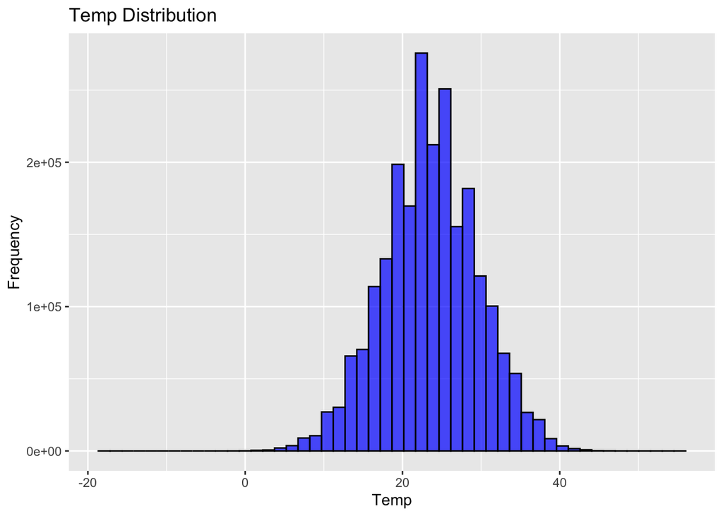

```r
ggplot(ss_met, aes(x = temp)) +
  geom_histogram(bins=50, fill = "blue", color = "black", alpha = 0.7) +
  labs(title = "Temp Distribution", x = "Temp", y = "Frequency")
```

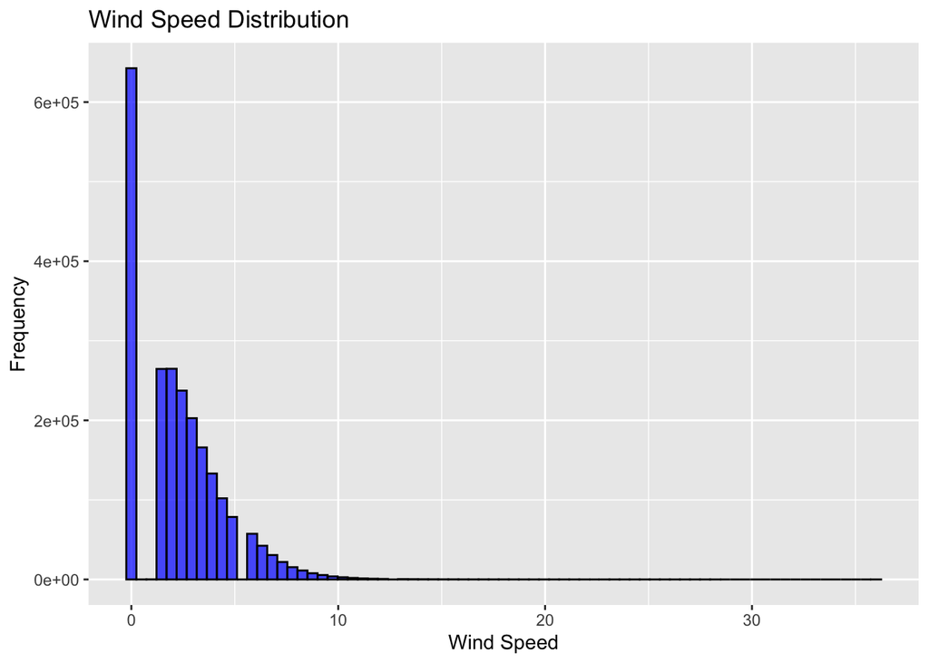

```r
ggplot(ss_met, aes(x = wind.sp)) +
  geom_histogram(bins=75, fill = "blue", color = "black", alpha = 0.7) +
  labs(title = "Wind Speed Distribution", x = "Wind Speed", y = "Frequency")
```

One thing we should consider for later analyses is to log transform wind speed and elevation as the are very skewed.

```r
met_transformed <- ss_met
met_transformed$wind.sp <- log(met_transformed$wind.sp)
met_transformed$elev <- log(met_transformed$elev)
na.omit(met_transformed)
```

[output not shown]

[output cut: 9990 more lines]

```r
summary(met_transformed)
```

```
##      USAFID            WBAN            year          month        day
##  Min.   :690150   Min.   :  116   Min.   :2019   Min.   :8   Min.   : 1
##  1st Qu.:720928   1st Qu.: 3706   1st Qu.:2019   1st Qu.:8   1st Qu.: 8
##  Median :722728   Median :13860   Median :2019   Median :8   Median :16
##  Mean   :723100   Mean   :29539   Mean   :2019   Mean   :8   Mean   :16
##  3rd Qu.:725090   3rd Qu.:54767   3rd Qu.:2019   3rd Qu.:8   3rd Qu.:24
##  Max.   :726813   Max.   :94998   Max.   :2019   Max.   :8   Max.   :31
##
##       hour            min             lat             lon
##  Min.   : 0.00   Min.   : 0.00   Min.   :24.55   Min.   :-124.29
##  1st Qu.: 5.00   1st Qu.:23.00   1st Qu.:33.97   1st Qu.: -98.02
##  Median :11.00   Median :50.00   Median :38.35   Median : -91.71
##  Mean   :11.34   Mean   :39.56   Mean   :37.94   Mean   : -92.15
##  3rd Qu.:17.00   3rd Qu.:55.00   3rd Qu.:41.94   3rd Qu.: -82.99
##  Max.   :23.00   Max.   :59.00   Max.   :48.94   Max.   : -68.31
##
##       elev          wind.sp           temp
##  Min.   : -Inf   Min.   :-Inf    Min.   :-17.20
##  1st Qu.:4.615   1st Qu.:-Inf    1st Qu.: 19.60
##  Median :5.529   Median :0.74    Median : 23.50
##  Mean   : -Inf   Mean   :-Inf    Mean   : 23.59
##  3rd Qu.:5.992   3rd Qu.:1.28    3rd Qu.: 27.80
##  Max.   :8.322   Max.   :3.58    Max.   : 56.00
##  NA's   :1509    NA's   :79693   NA's   :60125
```

### 9. Exploratory graphs: Time Series

Look at the time series of temperature and wind speed at this location. For this we will need to create a date-time variable for the x-axis.

```r
# <place your code here>

# Create a DateTime column
met_clean$DateTime <- as.POSIXct(
  paste(met_clean$year, met_clean$month, met_clean$day, met_clean$hour, sep = "-"),
  format = "%Y-%m-%d-%H"
)

head(met_clean)
```

| USAFID | WBAN | year | month | day | hour | min | lat | lon | elev | wind.sp | temp | DateTime |
| --- | --- | --- | --- | --- | --- | --- | --- | --- | --- | --- | --- | --- |
| 720385 | 419 | 2019 | 8 | 1 | 0 | 36 | 39.8 | -105.766 | 4113 | 8.8 | 9 | 2019-08-01 00:00:00 |
| 720385 | 419 | 2019 | 8 | 1 | 0 | 54 | 39.8 | -105.766 | 4113 | 2.6 | 9 | 2019-08-01 00:00:00 |
| 720385 | 419 | 2019 | 8 | 1 | 1 | 12 | 39.8 | -105.766 | 4113 | 3.1 | 9 | 2019-08-01 01:00:00 |
| 720385 | 419 | 2019 | 8 | 1 | 1 | 35 | 39.8 | -105.766 | 4113 | 4.1 | 9 | 2019-08-01 01:00:00 |
| 720385 | 419 | 2019 | 8 | 1 | 1 | 53 | 39.8 | -105.766 | 4113 | 4.6 | 9 | 2019-08-01 01:00:00 |
| 720385 | 419 | 2019 | 8 | 1 | 2 | 12 | 39.8 | -105.766 | 4113 | 6.2 | 9 | 2019-08-01 02:00:00 |

With the date-time variable we can plot the time series of temperature and wind speed. Summarize any trends that you see in these time series plots.

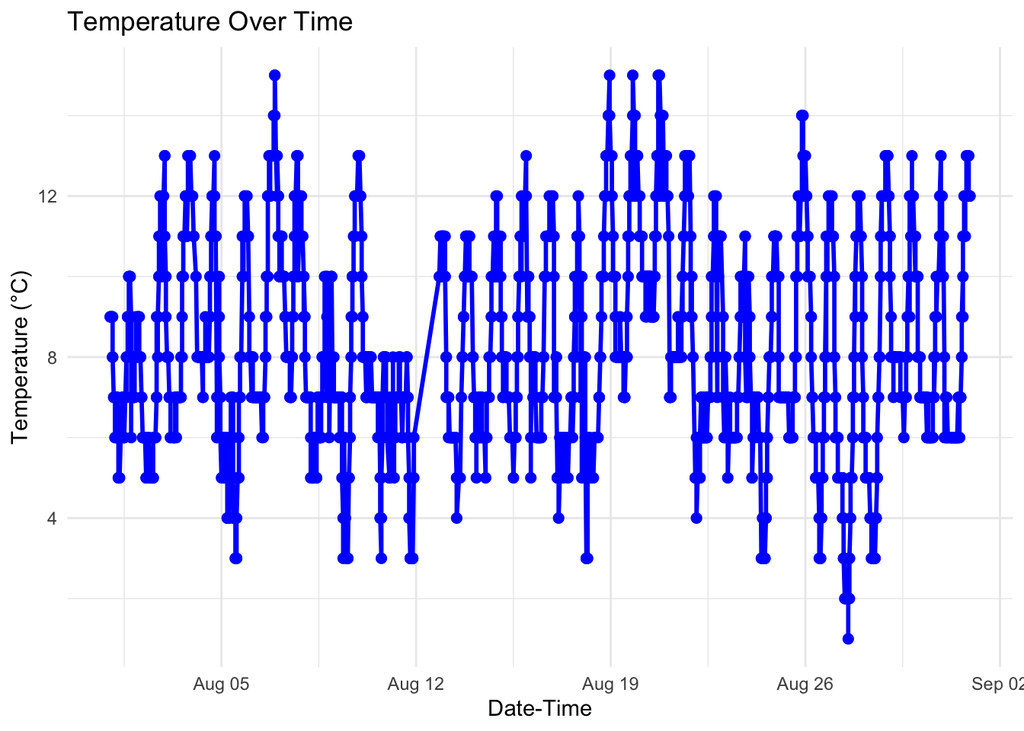

```r
# <place your code here>

ggplot(met_clean, aes(x = DateTime, y = temp)) +
  geom_line(color = "blue", size = 1) +
  geom_point(color = "blue", size = 2) +
  labs(title = "Temperature Over Time", x = "Date-Time", y = "Temperature (°C)") +
  theme_minimal()
```

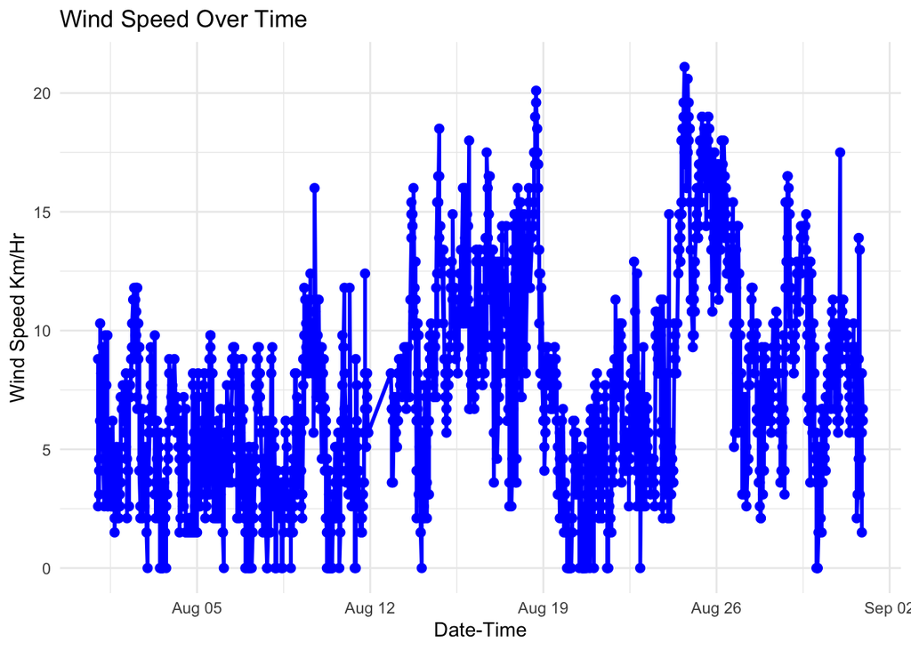

```r
ggplot(met_clean, aes(x = DateTime, y = wind.sp)) +
  geom_line(color = "blue", size = 1) +
  geom_point(color = "blue", size = 2) +
  labs(title = "Wind Speed Over Time", x = "Date-Time", y = "Wind Speed Km/Hr") +
  theme_minimal()
```

### 10. Exploratory graphs: Map

Where is the weather station with highest elevation located? (i.e. make a map!)

```r
# <place your code here>
# hint: make use of leaflet

met_stations <- (unique(met_clean[,c("lat", "lon")]))

leaflet(met_stations) %>%
    addProviderTiles('CartoDB.Positron') %>%
    addCircles(lat = ~lat, lng = ~lon, opacity = 1, fillOpacity = 1, radius = 100)
```

[interactive chart not shown]